# 2D Clouds

In this tutorial, we’re going to create animated procedural clouds that cast shadows over your game level. This shader is intended for top-down 2D games.

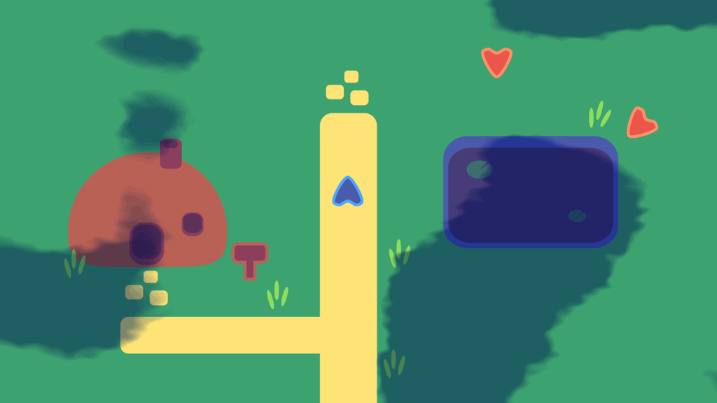

You are going to learn to:

- Generate animated clouds using simplex noise.
- Warp a texture using another texture.
- Use a 2D shader render mode.
- Put gradient mapping into practice.

Let’s get started.

## Scene Setup

The setup on this scene is minimal. We need some background sprites as we’ll overlay the cloud shadows over it. We also need a *Sprite* at the bottom of the node tree to represent our cloud layer.

For the background, you can find an adventure game mock-up in the Godot project: `topdown-adventure.svg`.

Here is my scene’s setup:

[figure not shown]

Assign a new noise texture to the *Texture* property with an Open Simplex Noise resource.

The most important change to make at this point is to set the texture to be *Seamless* so we can repeat it in our shader. I invite you to tweak the noise settings later on, once we have some of our shader’s code in place.

Here are the parameters I used for reference.

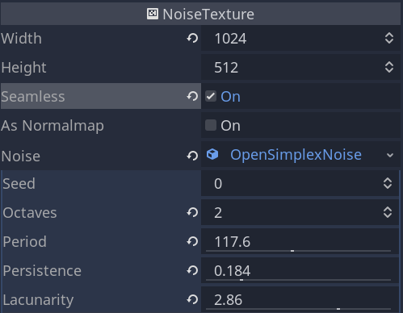

## Creating the shader

We need to create another noise texture to warp the first one, but we first need to create the shader and define a uniform to that end.

Create a new *ShaderMaterial* with a *Shader* resource.

It should be of type `canvas_item`. Add a uniform `sampler2D` in which we will store our second noise.

```
shader_type canvas_item;

uniform sampler2D noise_texture2 :hint_black;

void fragment() {
}
```

In the Inspector, under *Shader Param*, create a new noise texture with a noise generator different from the first one. We are going to use this other texture to warp the sampling of our first noise.

Here are my settings.

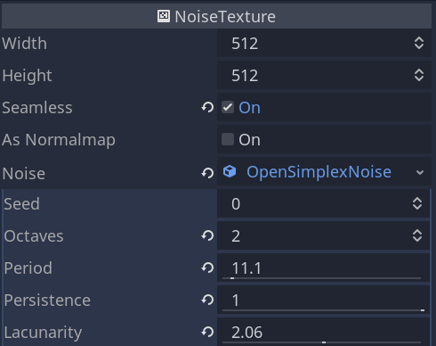

## Warping the noise

We can now start to animate our noises.

We want to use two layers of noise moving in different directions and at different speeds. When mixing them, doing so will simulate the edges of the clouds evolving.

The first noise is provided by our texture variable and the second one by the `noise_texture2` uniform. For each of them, we want three parameters: a scroll direction, a timescale, and a tile factor to control the scale of the clouds. Create two groups of three uniforms like so:

```
uniform vec2 scroll_direction1 = vec2(0.7, -0.7);
uniform float time_scale1 :hint_range(0.001, 0.25) = 0.012;
uniform float tile_factor1 :hint_range(0.1, 3.0) = 0.6;

uniform vec2 scroll_direction2 = vec2(0.75, 0.25);
uniform float time_scale2 :hint_range(0.001, 0.25) = 0.005;
uniform float tile_factor2 :hint_range(0.1, 3.0) = 0.3;
```

The scroll direction should be a unit vector that represents a direction to move towards in UV space.

Let’s use the `TIME` variable and the uniforms we just defined to animate the second noise. To do so, multiply the `UV` by `tile_factor2` and add the product of `scroll_direction2 * TIME * time_scale2`. That expression controls the texture’s panning.

Sample the noise texture using these UV coordinates.

```
void fragment() {
    vec2 noise2_uv = UV * tile_factor2 + scroll_direction2 * TIME * time_scale2;
    float noise2 = texture(noise_texture2, noise2_uv).r;
```

I’m only extracting a floating-point value from the noise because all three color channels contain the same data.

```
vec2 noise1_uv = UV * tile_factor1 + scroll_direction1 * TIME * time_scale1;
```

```
float noise1 = texture(TEXTURE, noise1_uv + noise2 * 0.02).r;
```

Use a small multiplier to control the warp effect’s strength. The offset caused by `noise2` is in UV space, so even a little value can cause significant changes.

If the offset is too big, the noise patterns will turn into lava or thin stretched curves, like the rings of a tree’s bark.

To visualize the result, convert your noise value into an RGB color:

```
COLOR.rgb = vec3(noise1);
```

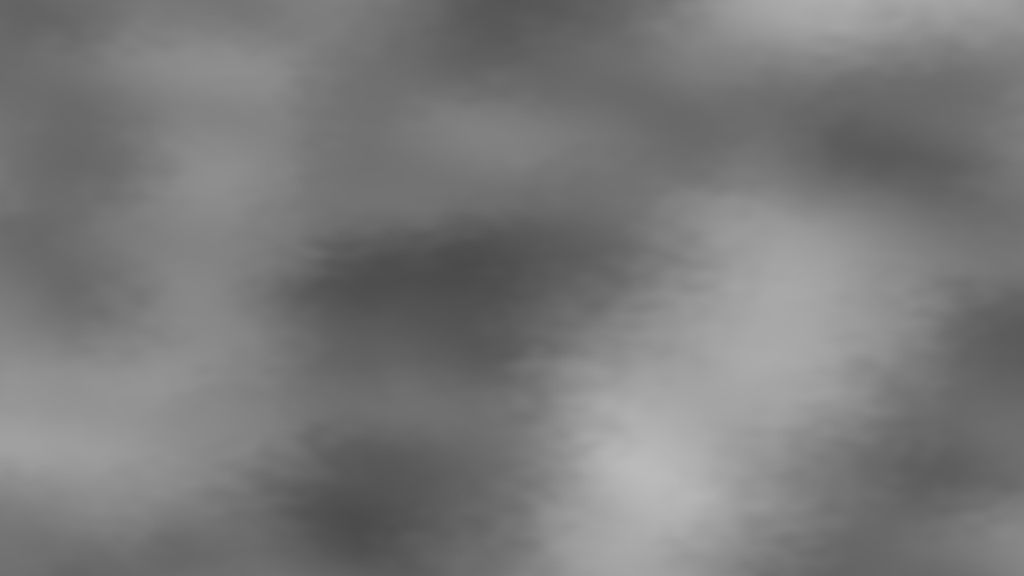

At this point, your shader’s code should look like so:

```
shader_type canvas_item;

uniform sampler2D noise_texture2 :hint_black;

uniform vec2 scroll_direction1 = vec2(0.7, -0.7);
uniform float time_scale1 :hint_range(0.001, 0.25) = 0.012;
uniform float tile_factor1 :hint_range(0.1, 3.0) = 0.6;

uniform vec2 scroll_direction2 = vec2(0.75, 0.25);
uniform float time_scale2 :hint_range(0.001, 0.25) = 0.005;
uniform float tile_factor2 :hint_range(0.1, 3.0) = 0.3;

void fragment() {
    vec2 noise2_uv = UV * tile_factor2 + scroll_direction2 * TIME * time_scale2;
    float noise2 = texture(noise_texture2, noise2_uv).r;

    vec2 noise1_uv = UV * tile_factor1 + scroll_direction1 * TIME * time_scale1;
    float noise1 = texture(TEXTURE, noise1_uv + noise2 * 0.02).r;
}
```

## Turning the noise into clouds

To turn our smooth noise into clouds, we need to increase its value contrast.

You can do so using the `smoothstep()` function, which smoothly interpolates between two values.

```
float clouds = smoothstep(0.45, 0.55, noise1);
```

The first two arguments define the range in which we want to interpolate the third argument. With this function, if `noise1` is lower than `0.45`, we get `0.0`. If it’s greater than `0.55`, we get `1.0`. And if `noise1` is within the `[0.45, 0.55]` range, the function outputs values between `0.0` and `1.0`.

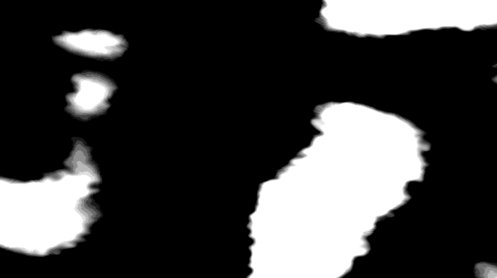

At this stage, you want to play with your two noise generators’ parameters and with the smoothstep function’s values. You should see cloud-like shapes appear.

## Real-time feedback with gradient mapping

While the `smoothstep()` function works, we are going to use gradient mapping to have real-time control over our noise’s contrast.

Create a new uniform, `sampler2D`.

```
uniform sampler2D gradient_texture :hint_black;
```

In the Inspector, assign a new *GradientTexture* to it with a *Gradient* resource. You want to move the black, and the white color stops close to one another to produce an effect similar to the `smoothstep()` function.

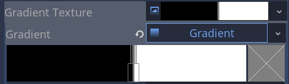

Back in the shader, use the gradient mapping technique you learned in the previous lesson to remap the noise to the value range defined by the gradient.

```
float clouds = texture(gradient_texture, vec2(noise1, 0.0)).r;
```

Output your `clouds` values to the screen and move the color stops in the Inspector to see how the gradient turns your noise into clouds.

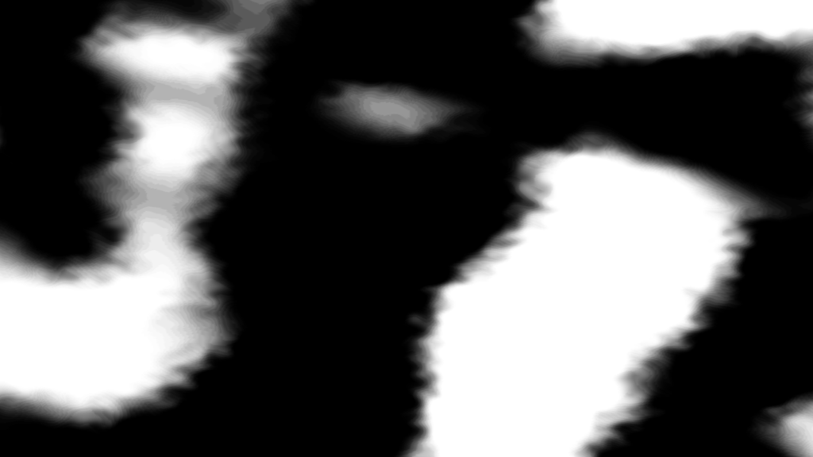

## Turning the noise into shadows

We now have two steps left:

1. Tinting our clouds.
2. Multiplying the inverse of the clouds’ values over the screen.

Create a new uniform to represent a tint that we’ll apply to the clouds mask.

```
uniform vec4 tint :hint_color = vec4(0.0);
```

To turn our shader’s output into a shade, we can use the `blend_mul` render mode. Right after the `shader_type`, add the following line:

```
render_mode blend_mul;
```

Doing so makes the output of our shader use the multiply blending mode. This allows us to add shadows over the game world without having to sample the screen texture.

We need to output dark colors where our clouds are, and white where we do not want any shadows. We can do so using the `mix()` function:

```
COLOR.rgb = mix(vec3(1.0), tint.rgb, clouds * tint.a);
```

The line above uses our `clouds` to interpolate between white and our `tint` color. We also use the alpha channel of our `tint` to control the opacity of the shadows.

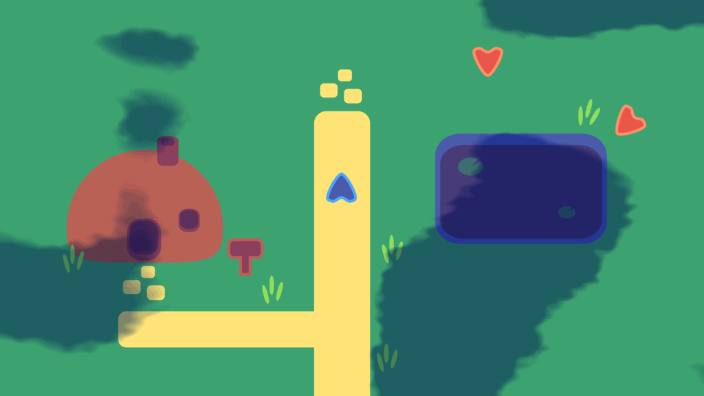

Here is the final code:

```
shader_type canvas_item;
render_mode blend_mul;

uniform vec4 tint :hint_color = vec4(0.0);
uniform sampler2D noise_texture2 :hint_black;
uniform sampler2D gradient_texture :hint_black;

uniform vec2 scroll_direction1 = vec2(0.7, -0.7);
uniform float time_scale1 :hint_range(0.001, 0.25) = 0.012;
uniform float tile_factor1 :hint_range(0.1, 3.0) = 0.6;

uniform vec2 scroll_direction2 = vec2(0.75, 0.25);
uniform float time_scale2 :hint_range(0.001, 0.25) = 0.005;
uniform float tile_factor2 :hint_range(0.1, 3.0) = 0.3;

void fragment() {
    vec2 noise2_uv = UV * tile_factor2 + scroll_direction2 * TIME * time_scale2;
    float noise2 = texture(noise_texture2, noise2_uv).r;

    vec2 noise1_uv = UV * tile_factor1 + scroll_direction1 * TIME * time_scale1;
    float noise1 = texture(TEXTURE, noise1_uv + noise2 * 0.02).r;

    float clouds = texture(gradient_texture, vec2(noise1, 0.0)).r;
    COLOR.rgb = mix(vec3(1.0), tint.rgb, clouds * tint.a);
}
```